# MAT02014 - Planejamento de Experimentos II Experimentos com múltiplos fatores

Rodrigo Citton P. dos Reis `rodrigocpdosreis@gmail.com` Universidade Federal do Rio Grande do Sul Instituto de Matemática e Estatística Departamento de Estatística

Porto Alegre, 2018

# Delineamentos fatoriais com múltiplos fatores

## Introdução

- Vimos que delineamentos fatoriais de dois fatores são mais eficientes do que estudar cada fator separadamente em projetos de um fator.
- Da mesma forma, quando muitos fatores estão em estudo, é mais eficiente estudá-los juntos em um planejamento fatorial **multifatorial** do que estudá-los separadamente em grupos de dois usando delineamentos fatoriais de dois fatores.
- Quando múltiplos fatores são estudados simultaneamente, o poder para detectar efeitos principais é maior sobre o que seria em experimentos fatoriais separados de dois fatores.
- Além disso, a possibilidade de detectar interações entre qualquer um dos fatores é possível.

## Introdução

- Se os fatores fossem estudados separadamente (em delineamentos fatoriais de dois fatores), interações de dois fatores só poderiam ser detectadas entre fatores estudados juntos no mesmo desenho.
- Em um fatorial multifatorial, não só é possível detectar interações de dois fatores entre qualquer par de fatores, mas também é possível detectar **interações de ordem superior** entre grupos de fatores.
- Uma interação de três fatores entre os fatores $A$, $B$ e $C$, por exemplo, significa que o efeito do fator $A$ difere dependendo da combinação dos níveis dos fatores $B$ e $C$.

## Introdução

- As combinações de **tratamento** em um fatorial multifatorial consistem em todas as combinações possíveis dos níveis de todos os fatores.
- **Pergunta 1:** Faça a combinação dos níveis de 3 fatores, no caso em que cada um destes apresenta dois níveis.
- **Pergunta 2:** Como você faria isto no seu software?
- O modelo para análise é uma extensão do modelo proposto para delineamentos fatoriais de dois fatores, e a análise pode ser feita usando a função `lm` do `R` similar aos exemplos mostrados anteriormente.

## Exemplo

- Considere um exemplo de um planejamento fatorial multifatorial em pesquisa de *marketing*.
- Uma empresa cujas vendas são feitas *on-line* por meio de uma página da *Web* gostaria de aumentar a proporção de visitantes de seu site que se inscrevem em seus serviços configurando de forma ideal sua página da *web*.

## Exemplo

- Para comprar na empresa, os clientes devem se inscrever e preencher um formulário fornecendo seu endereço de *e-mail* junto com outros campos necessários.
- Uma vez que um cliente se inscreve, a empresa tem informações de contato para seu banco de dados e pode enviar por *e-mail* com propagandas, ofertas especiais e assim por diante.
- A empresa gostaria de experimentar testando diferentes configurações de sua página da *Web* para ver se eles podem aumentar o número de visitantes do site que realmente se inscreveram.

## Exemplo

- As unidades experimentais neste estudo serão os indivíduos que visitam o site da empresa.
- A resposta é **binária**: o cliente ou **se inscreve** ou **não se inscreve**.
- Os fatores em estudo são características que alteram a aparência da página da *Web*.
  - O **fator $A$** representa as alternativas de segundo plano (plano de fundo) para a página com três opções.
  - O **fator $B$** é o tamanho da fonte na faixa principal, com três níveis.
  - O **fator $C$** é a cor do texto, com duas alternativas.
  - O **fator $D$** é uma escolha entre um botão de inscrição ou um link.

## Exemplo

- Com base nesses fatores, existem **3 × 3 × 2 × 2 = 36** possíveis configurações da página da Web ao considerar todas as combinações possíveis dos níveis de cada fator.
- Um experimento fatorial de **quatro fatores** consiste em atribuir aleatoriamente visitantes ao site a uma das possíveis configurações e registrar sua resposta binária.
- Existem variáveis ocultas que podem afetar a chance de um visitante do site se inscrever.
  - Por exemplo, a ordem de posição em que o link (para o site da empresa) aparece em uma pesquisa na Web para os produtos que eles vendem, promoções oferecidas pelos concorrentes e atratividade dos sites dos concorrentes.
- A designação aleatória de cada visitante sequencial do site para uma das configurações alternativas em estudo deve minimizar a chance de viés de alterações nas variáveis ocultas ao longo do tempo.

## *Das model*

[figure not shown]

## *Das model*

- A probabilidade de um visitante do site se inscrever pode ser expressa pelo modelo:

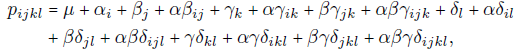

- $\alpha_i$ representa o efeito do plano de fundo;
- $\beta_j$ representa o efeito do tamanho da fonte na faixa principal;
- $\gamma_k$ representa o efeito da cor do texto;
- $\delta_l$ representa o efeito do botão *vs* o link para inscrição.

## Exemplo

- O experimento foi conduzido através da construção de 36 sites, consistindo de todas as combinações possíveis dos quatro fatores descritos.
- Cada cliente em potencial que visitou o site da empresa durante o período de teste foi redirecionado **aleatoriamente** para uma das 36 configurações.
- O número de visitantes $n_{ijkl}$ da versão $ijkl$ e o número que se inscreveu $x_{ijkl}$ foram registrados.
- O $x_{ijkl}$ é então distribuído conforme uma distribuição binomial:

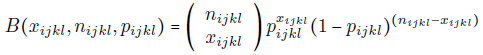

## Exemplo (R)

```r
library(daewr)
data(web)
head(web)
```

```
##   A B C D visitors signup
## 1 1 1 1 1     1016     22
## 2 1 1 1 2     1145     16
## 3 1 1 2 1     1145     17
## 4 1 1 2 2     1082     19
## 5 1 2 1 1     1121     28
## 6 1 2 1 2     1103     28
```

## Exemplo

- Poderíamos tentar transformar os dados (as proporções amostrais).
- Uma alternativa mais elegante, e com resultados teóricos interessantes é o uso do **modelo logístico**.
- O modelo logístico é um modelo que faz parte da classe dos **modelos lineares generalizados** (*MLG* ou *GLM*).

### (Pausa)

- Para avaliarmos as hipóteses usuais, utilizaremos a **análise do desvio** (*Analys of Deviance*; ANODEV).
  - É uma generalização da análise de variância para os MLG.

## Exemplo (R)

- **Sua vez:** ao nível de 5% de significância, o que podemos falar dos efeitos principais? E dos efeitos de interação?

```r
modb <- glm( cbind(signup, visitors-signup) ~ A * B * C * D,
             data = web, family = binomial )
anova(update(modb, .~ A+B + A:B + C + A:C + B:C + A:B:C + D + A:D + B:D + A:B:D + C:D + A:C:D + B:C:D + A:B:C:D),
      test = "Chisq")
```

```
## Analysis of Deviance Table
##
## Model: binomial, link: logit
##
## Response: cbind(signup, visitors - signup)
##
## Terms added sequentially (first to last)
##
##
##         Df Deviance Resid. Df Resid. Dev Pr(>Chi)
## NULL                       35     56.641
## A        2  10.2540        33     46.387 0.005934 **
## B        2   6.9301        31     39.457 0.031272 *
## C        1   2.9632        30     36.493 0.085182 .
## D        1   4.6165        29     31.877 0.031666 *
## A:B      4   6.3093        25     25.568 0.177213
## A:C      2   0.6821        23     24.886 0.711026
## B:C      2   4.0303        21     20.855 0.133300
## A:D      2   0.2807        19     20.575 0.869069
## B:D      2   3.7705        17     16.804 0.151793
## C:D      1   0.0783        16     16.726 0.779629
## A:B:C    4   2.2127        12     14.513 0.696712
## A:B:D    4   6.3323         8      8.181 0.175671
## A:C:D    2   6.1525         6      2.028 0.046132 *
## B:C:D    2   0.0219         4      2.007 0.989104
## A:B:C:D  4   2.0065         0      0.000 0.734562
## ---
## Signif. codes:  0 '***' 0.001 '**' 0.01 '*' 0.05 '.' 0.1 ' ' 1
```

## Exemplo (R)

```r
prop <- web$signup / web$visitors
webp <- data.frame(web, prop)
par(mfrow = c(1,3))
webp1 <- subset(webp, A == 1)
interaction.plot(webp1$C, webp1$D, webp1$prop, type = "l",
                 legend=FALSE, ylim = c(.015,.0275), main = "Background = 1",
                 xlab = "Text Color", ylab = "Proportion Signing-up")
webp2 <- subset(webp, A == 2 )
interaction.plot( webp2$C, webp2$D, webp2$prop, type = "l", legend = FALSE, ylim = c(.015,.0275), main = "Background = 2",
                  xlab = "Text Color", ylab = " ")
lines( c(1.7,1.85), c(.016,.016), lty = 2)
lines( c(1.7,1.85), c(.017,.017) ,lty = 1)
text(1.3, .017, "Sign-up link ")
text(1.3, .016, "Sign-up Button" )
text(1.4, .018, "LEGEND" )
webp3 <- subset(webp, A == 3)
interaction.plot(webp3$C, webp3$D, webp3$prop, type = "l",
                 legend=FALSE, ylim = c(.015,.0275), main="Background = 3",
                 xlab = "Text Color", ylab = " ")
```

## Exemplo (R)

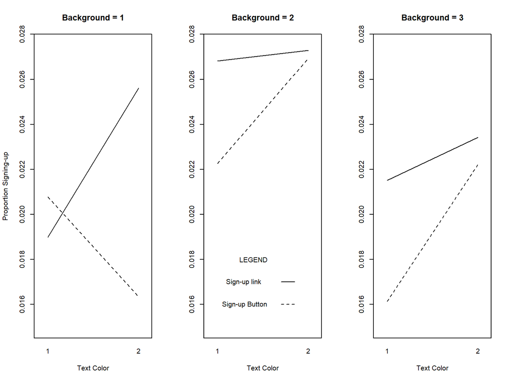

## Conclusões

- Ao usar o tipo de segundo plano 2 ou tipo 3, pode-se observar que a alteração da cor do texto de preto = 1 para branco = 2 causa um aumento na proporção de visitantes do site que se inscrevem.
- O aumento (representado pela inclinação das linhas) é maior quando um botão de inscrição é usado, em vez de um link de inscrição, porque a taxa de inscrição geral é maior quando um link é usado, independentemente da cor do texto.
  - Não há muito espaço para melhorias.
- No entanto, quando o tipo de plano de fundo 1 é usado, o efeito da cor do texto é completamente diferente.
  - Nesse caso, alterar a fonte de preto = 1 para branco = 2 causa uma diminuição na proporção quando um botão de inscrição é usado, e há um grande aumento na proporção de inscristos ao mudar de fonte preta para branca ao usar um link de inscrição.
  - Este é o oposto dos efeitos vistos para os tipos de fundo 2 e 3.

## Para casa (para aula)

- Construa a tabela de análise de variância para o caso multifatorial com resposta normal.
- Discuta outras aplicações que você considera que o delineamento fatorial com múltiplos fatores é apropriado.